# Discovery-Hiring-Analyst-2016

# Task

## You must create a reproducible report* answering the following questions:

1. What is our daily overall clickthrough rate? How does it vary between the groups?
2. Which results do people tend to try first? How does it change day-to-day?
3. What is our daily overall zero results rate? How does it vary between the groups?
4. Let session length be approximately the time between the first event and the last event in a session. Choose a variable from the dataset and describe its relationship to session length. Visualize the relationship.
5. Summarize your findings in an executive summary.

# Data

> The dataset comes from a tracking schema that we use for assessing user satisfaction. Desktop users are randomly sampled to be anonymously tracked by this schema which uses a “I’m alive” pinging system that we can use to estimate how long our users stay on the pages they visit. The dataset contains just a little more than a week of EL data.

## Column Value Description

1. uuid string Universally unique identifier (UUID) for backend event handling.
2. timestamp integer The date and time (UTC) of the event, formatted as YYYYMMDDhhmmss.
3. session_id string A unique ID identifying individual sessions.
4. group string A label (“a” or “b”).
5. action string Identifies in which the event was created. See below.
6. checkin integer How many seconds the page has been open for.
7. page_id string A unique identifier for correlating page visits and check-ins.
8. n_results integer Number of hits returned to the user. Only shown for searchResultPage events.
9. result_position integer The position of the visited page’s link on the search engine results page (SERP).

https://github.com/wikimedia-research/Discovery-Hiring-Analyst-2016

# Import libraries

```r
# Import some libraries
library(ggplot2)
library(plyr)
library(dplyr)
library(gridExtra)
```

# Import and clean data

```r
# Import dataset CSV and explicitly cast each column type
events <- read.table(
  file = "C:/Users/Eirika/Documents/Code/Datasets/events_log/events_log.csv",
  sep = ",", header = TRUE,
  colClasses =  (
    c(
      "character",
      "character",
      "character",
      "character",
      "character",
      "integer",
      "character",
      "integer",
      "integer"
    )
  ))
# Use format mask for timestamps in UTC/GMT
strptime(events$timestamp, "%Y%m%d%H%M%S", tz = "GMT")
```

[output not shown]

[output cut: 321 more lines]

## 1. What is our daily overall clickthrough rate? How does it vary between the groups?

> Group A makes up the bulk of the clickthrough events, whereas group B has far fewer.

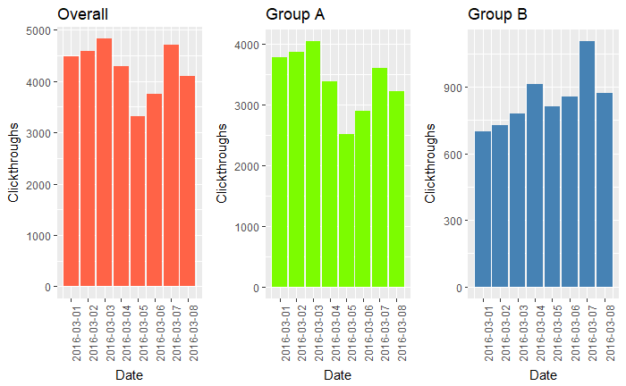

```r
# Pull out data only of visitPage clickthrough events
clickthrough <- events[events$action == 'visitPage',]
# Pull out clickthroughs that resulted from non-NA result position
clickthrough <- clickthrough[!is.na(clickthrough$result_position),]
# Chart by day
cpd <- ggplot(clickthrough, aes(x=as.POSIXct(clickthrough$timestamp, "%Y%m%d", tz = "GMT"))) + scale_x_datetime(date_breaks = "1 day") + labs(title= "Overall",x="Date", y="Clickthroughs") + geom_bar(fill="tomato") + theme(axis.text.x=element_text(angle=90), axis.text.y=element_text(angle=0))
# Chart per group a and b
groupa <- clickthrough[clickthrough$group == 'a',]
groupb <- clickthrough[clickthrough$group == 'b',]
cpda <- ggplot(groupa, aes(x=as.POSIXct(groupa$timestamp, "%Y%m%d", tz = "GMT"))) + scale_x_datetime(date_breaks = "1 day") + labs(title= "Group A",x="Date", y="Clickthroughs") + geom_bar(fill="lawngreen") + theme(axis.text.x=element_text(angle=90), axis.text.y=element_text(angle=0))
cpdb <- ggplot(groupb, aes(x=as.POSIXct(groupb$timestamp, "%Y%m%d", tz = "GMT"))) + scale_x_datetime(date_breaks = "1 day") + labs(title= "Group B", x="Date", y="Clickthroughs") + geom_bar(fill="steelblue") + theme(axis.text.x=element_text(angle=90), axis.text.y=element_text(angle=0))
grid.arrange(cpd, cpda, cpdb, ncol=3)
```

```r
# Overall daily clickthrough rate
count(as.POSIXct(clickthrough$timestamp, "%Y%m%d", tz = "GMT"))
```

```
           x freq
1 2016-03-01 4477
2 2016-03-02 4595
3 2016-03-03 4823
4 2016-03-04 4294
5 2016-03-05 3322
6 2016-03-06 3756
7 2016-03-07 4714
8 2016-03-08 4098
```

```r
# Group A clickthrough rate
count(as.POSIXct(groupa$timestamp, "%Y%m%d", tz = "GMT"))
```

```
           x freq
1 2016-03-01 3779
2 2016-03-02 3868
3 2016-03-03 4042
4 2016-03-04 3381
5 2016-03-05 2512
6 2016-03-06 2899
7 2016-03-07 3610
8 2016-03-08 3228
```

```r
# Group B clickthrough rate
count(as.POSIXct(groupb$timestamp, "%Y%m%d", tz = "GMT"))
```

```
           x freq
1 2016-03-01  698
2 2016-03-02  727
3 2016-03-03  781
4 2016-03-04  913
5 2016-03-05  810
6 2016-03-06  857
7 2016-03-07 1104
8 2016-03-08  870
```

```r
# How large is each group?
groupsize <- count(events$group)
print(groupsize)
```

```
  x   freq
1 a 299019
2 b 101146
```

## 2. Which results do people tend to try first? How does it change day-to-day?

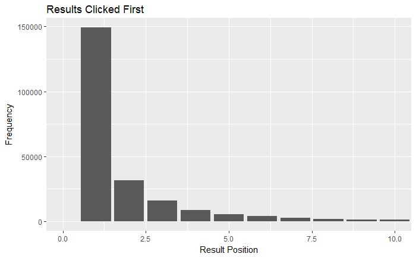

```r
# Pull out all data that have a results_position that is not null
results <- events[!(is.na(events$result_position)),]
# count(results$result_position) # for freq table
# Graph of distribution of results_position
rtf <- ggplot(results, aes(x=results$result_position)) + geom_bar() + coord_cartesian(xlim=c(0,10)) + labs(title = "Results Clicked First", x="Result Position", y= "Frequency")
print(rtf)
```

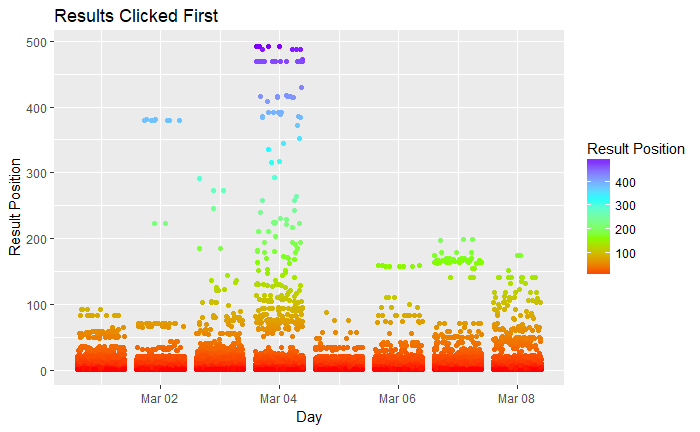

```r
# Zoom in on only result positions in the top 500
results_500 <- results[results$result_position < 500,]
days_500 <- ggplot(results_500, aes(x=as.POSIXct(results_500$timestamp, "%Y%m%d", tz = "GMT"), y=results_500$result_position, colour = results_500$result_position)) + geom_jitter() + labs(title = "Results Clicked First", x="Day", y= "Result Position", colour = "Result Position") + scale_colour_gradientn(colours=rainbow(4))
print(days_500)
```

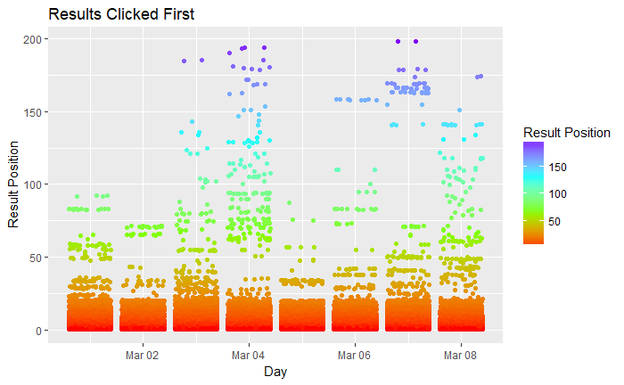

```r
# Zoom in on only result positions in the top 200
results_200 <- results_500[results_500$result_position < 200,]
days_200 <- ggplot(results_200, aes(x=as.POSIXct(results_200$timestamp, "%Y%m%d", tz = "GMT"), y=results_200$result_position, colour = results_200$result_position)) + geom_jitter() + labs(title = "Results Clicked First", x="Day", y= "Result Position", colour = "Result Position") + scale_colour_gradientn(colours=rainbow(4))
print(days_200)
```

## 3. What is our daily overall zero results rate? How does it vary between the groups?

> The daily overall zero results rate ranges between 10 and 15% each day. Group A is closer to the overall trend whereas Group b as a population displays less variability in zero results rate.

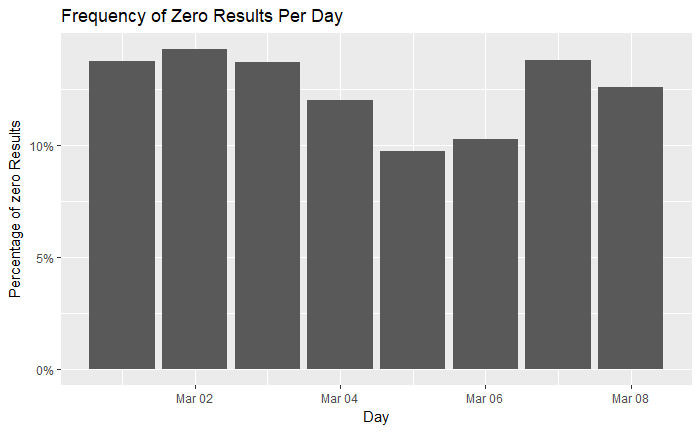

```r
# Pull out only search result page action
search_results <- events[events$action == "searchResultPage",]
# Pull out only n_results of 0, exclude N/A
not_na_results <- search_results[!is.na(search_results$n_results),]
zero_results <- not_na_results[not_na_results$n_results == 0,]
# Pull out group b and group A data
zero_a <- zero_results[zero_results$group == "a",]
zero_b <- zero_results[zero_results$group == "b",]
# Plot by day
zrpd <- ggplot(zero_results) + geom_bar(mapping = aes(x=as.POSIXct(zero_results$timestamp, "%Y%m%d", tz = "GMT"),y =..prop..), stat = "count", group = 1) + labs(title = "Frequency of Zero Results Per Day", x="Day", y= "Percentage of zero Results") + scale_y_continuous(labels = scales::percent_format())
# Plot by group
zra <- ggplot(zero_a) + geom_bar(mapping = aes(x=as.POSIXct(zero_a$timestamp, "%Y%m%d", tz = "GMT"),y =..prop..), stat = "count", group = 1) + labs(title = "Frequency of Zero Results Per Day", x="Day", y= "Percentage of zero Results") + scale_y_continuous(labels = scales::percent_format())
zrb <- ggplot(zero_b) + geom_bar(mapping = aes(x=as.POSIXct(zero_b$timestamp, "%Y%m%d", tz = "GMT"),y =..prop..), stat = "count", group = 1) + labs(title = "Frequency of Zero Results Per Day", x="Day", y= "Percentage of zero Results") + scale_y_continuous(labels = scales::percent_format())
print(zrpd)
```

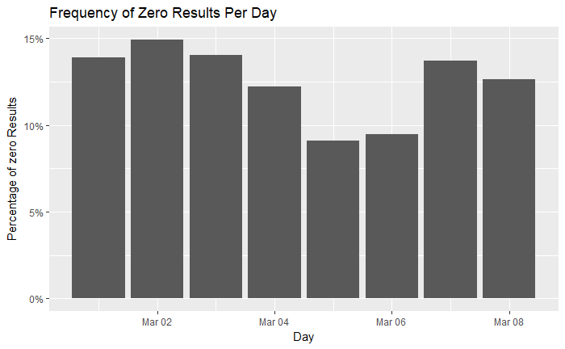

```r
print(zra)
```

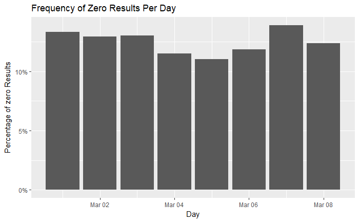

```r
print(zrb)
```

```r
# Print frequency chart comparing size of group a and b
print(groupsize)
```

```
  x   freq
1 a 299019
2 b 101146
```